# Part II - Ford GoBike System Data Exploration

## by Akbarali Mukhammadiev

## Investigation Overview

> I would like to investigate the dataset concerning the individual rides made in a bike-sharing system covering the greater San Francisco Bay area, United States in 2019. My exploration and visualization study primarily focuses on finding the bike usage pattern and customer habit characteristics from the 2nd month ride trips data in 2019. There are univariate, bivariate as well as multivariate investigations will be presented.

## Dataset Overview

> The given dataset includes information about individual rides made in a bike-sharing system covering the greater San Francisco Bay area, United States. The attributes included the trip start/end time, as well as additional measurements such as user type, gender, and age. Over 183000 data points are given in the dataset in overall 16 columns.

## Distribution of hourly and daily rides

> In this visualization, I will consider the information concerning the travel starting hours and the days when the travels took place. The most frequent hour of the day is 5:00 pm and the least frequent is after midnight. This is probably due to the fact that everyone returned home from their offices. the usage of bikes correspond to 24 hours in a day. Thursday is the day that the most rides took place following by Tuesday, Wdnesday etc. The weekends are the less popular days among travellers.

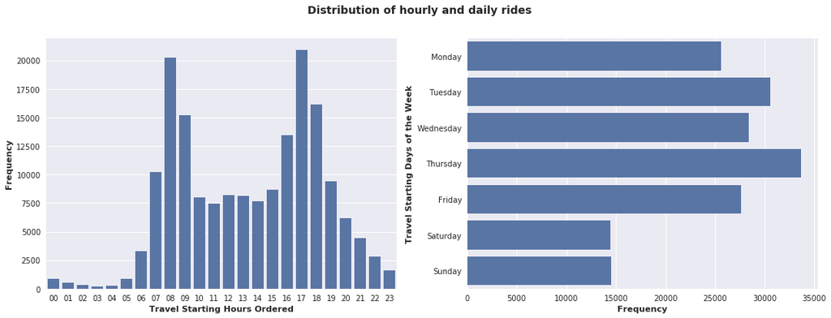

## Length of travel vs. gender and types of users

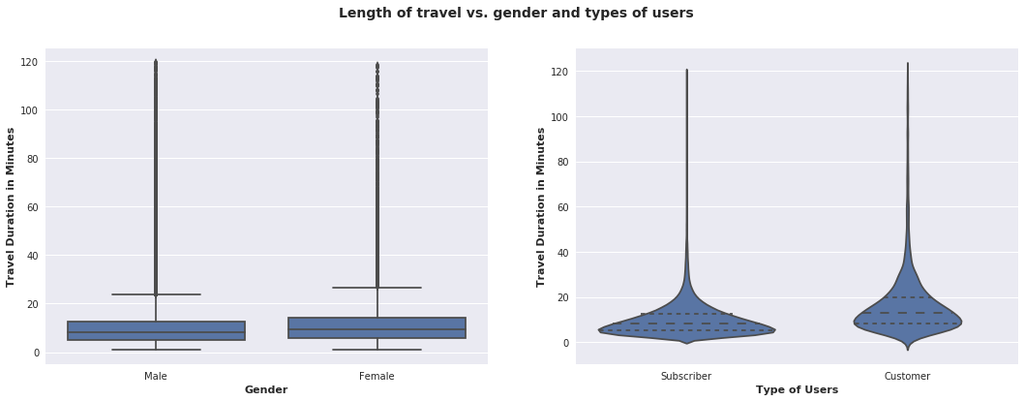

> In the final slide, I would like to present he fact that concerning the correation between the ages of the users and the average travel duration. We can see rather slightly negative correlation after the age of 20 between the two. After the age of 20, younger people travelled more than the older people. Moreover, the longest travel durations correspond the age interval between 20 and 30. Travel duration starts decreasing after the age 20.

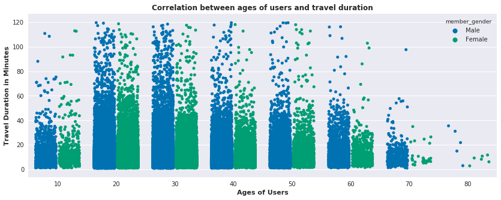